# Intro to PCA (Principal Component Analysis) - Part1

Recently I’ve been spending more and more time in the promised and promising land of data science and machine learning. Thanks to a good [friend of mine](https://twitter.com/stevegraham) I took the famous Coursera Machine Learning [course](https://www.coursera.org/learn/machine-learning/home/welcome) and although I was familiar with most of the algorithms introduced during the course, I really enjoyed dusting off the old knowledge.

One of the topics covered by the course is [Principal Component Analysis](https://en.wikipedia.org/wiki/Principal_component_analysis) (PCA). You can find a lot of information on the inernet about the topic, but most of it can feel a bit overwhelming to someone who is just starting to learn about it and doesn’t have a decent background in linear algebra. I wanted something which will not only summarise the “hard core” maths equations, but which will also illustrate the core concepts by looking at some practical examples.

The post will provide some code samples in [R](https://www.r-project.org/) programming language which has become an essential part of many data scientists’ toolboxes. The code samples will give you a chance to play around with real data and thus hopefully reinforce your understanding of the topic.

Let’s get started!

## Motivation

In our every day lives we are dealing with tremendous and increasingly growing amount of data. Our brain is so advanced that it filters out the important information from our environment often automatically without our realizing it. But even brain has its limits. When it comes to multidimensional data we find it hard to understand them as we naturally try to visualize them, which is not very easy when the data span arbitrary number of dimensions.

We tend to collect large amounts of data from various sources, because we often don’t know which data best reflects the system we are trying to understand. Our fear of missing on capturing important feature forces us to go “data-bonkers” and collect a lot of **redundant** data. This naturally leads to unnecessarily long data processing times. Furthermore, the collected data is inevitably clouded with noise which makes the understanding of it even harder: **We are dealing with big amount of redundant data clouded with noise!**.

We need to find a way to represent the collected data in a form that filters out the noise, reduces redundancy [and thus increases data processing efficiency], but still retains enough information we need to make sense of the data. This should not only give us faster data processing times, but also helps us visualize the data which is an important aspect of [Exploratory Data Analysis](https://en.wikipedia.org/wiki/Exploratory_data_analysis), a mandatory step of data analysis. This is where PCA comes to our rescue!

## Intuition

Imagine we are recording a runner on a running track using a camera from some arbitrary angle. The runner runs from one point to another and back until she gets tired and stops. For simplifcation we will be using an ancient camera, which has a tiny sampling rate of 5[Hz](https://en.wikipedia.org/wiki/Hertz). To make this even simpler, we will assume the runner is not very fit and is only capable of 10s of running. This will give us 50 data samples (10s x 5Hz) in 2D space i.e. 100 data points overall. This should be enough to illustrate the basic PCA concepts.

*(Obviously, in real life we might have a reasonably fit runner whose run is being recorded by multiple cameras at the same time with much higher sampling rate. Let’s say the runner stops running after 120s and there are 3 cameras, each with a sampling rate of 44kHz. This would give us 120s x 44000 Hz = 5,280,000 data samples in 3 axis x 3 cameras dimensional data space i.e. we would collect 47,520,000 data points! The speed of data processing and data visualization suddenly become real issues!)*

It’s obvious that unless the runner had a few drinks beforehands, his/her trajectory should be a straight(ish) line. In other words, we know that the runner runs in one direction identifiable by a simple line trajectory. Our camera however produces two data points on a 2D plance for each record it takes. This is clearly redundant. We will explain why on the following lines.

Let’s have a look first at the actual data from camera and create two scatter plots: one with only the raw data and another one which will have line copying the runner’s trajectory overlaid on the raw data:

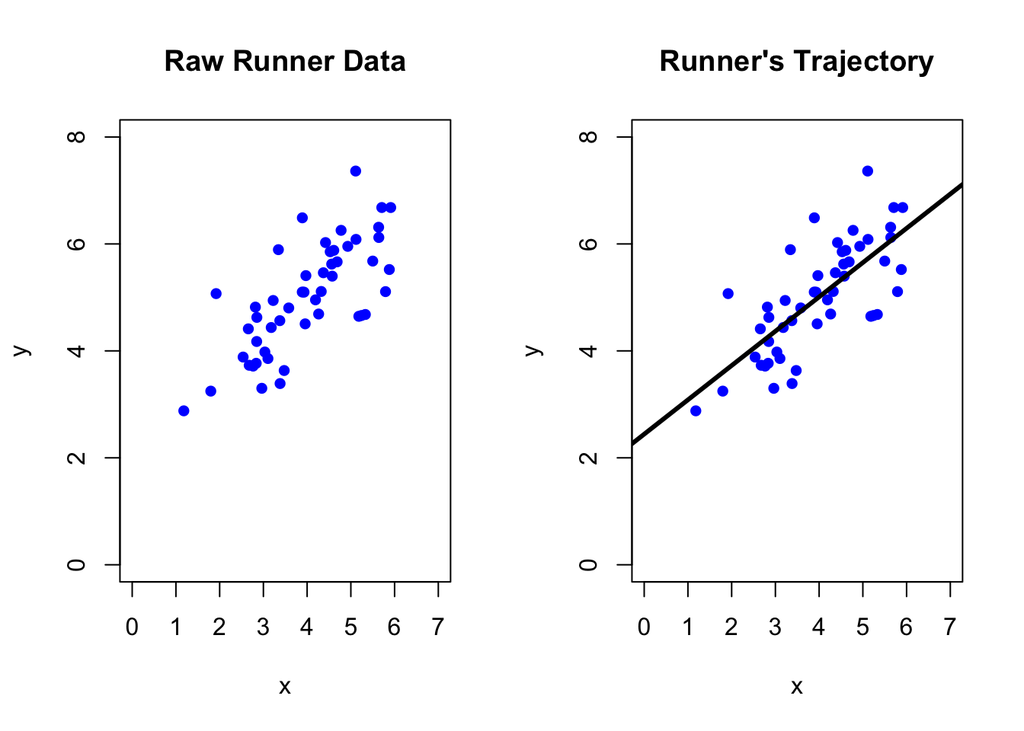

```r
# load R Matlab package
if (suppressMessages(!require(R.matlab))) {
        # install R.matlab package
        install.packages("R.matlab")
        suppressMessages(library(R.matlab))
}
# read in the data sample
data <- readMat("data.mat")
# extract (subset) x and y
x <- data$X[,1]
y <- data$X[,2]
# we want two plots in one row
par(mfrow=c(1,2))
plot(x, y, main = "Raw Runner Data", xlab="x", ylab="y", xlim = c(0,7), ylim = c(0,8), pch=16, col="blue")
plot(x, y, main = "Runner's Trajectory", xlab="x", ylab="y", xlim = c(0,7), ylim = c(0,8), pch=16, col="blue")
abline(lm(y~x), lwd = 3)
```

There are two things we can spot straight away from the generated plots. First of all, the camera angle is clearly not perpendicular to the running track, so the collected samples are a bit rotated around the camera angle. Second of all, we can see there is a clear correlation between $x$ and $y$ data points.

If we can figure out parameters of the trajectory line which we drew in the second plot, we can guess $y$ values based on $x$ and vice versa with some reasonably acceptable precision. In other words: the collected data set contains redundant data. There must be a way that allows us to transform the redundant data set into a smaller and simpler data set. This is the problem which the PCA algorithm tries to solve.

### Data matrix

Let’s sprinkle a bit of maths on the problem now. First, we will put all the measurements into data matrix $X$ line by line. The matrix will have $m$ rows (measurements) and $n$ columns (each for different types of measurements). Our data matrix has 50 rows and 2 columns which capture the runner’s movement along x and y axis on 2D plane (for brevity only the first three rows are displayed):

$\mathbf{X} = \left[\begin{array} {rrr} 5.635270 & 6.312114 \\ 4.686330 & 5.665241 \\ 2.850513 & 4.626456 \\ \vdots & \vdots \end{array}\right]$

Every measurement (row) in our matrix represents a two dimensional vector which lies in a two dimensional vector space defined by some (vector basis)[https://en.wikipedia.org/wiki/Basis_(linear_algebra)]. Wow, that was some serious linear algebra lingo! Let’s have a closer look at this to make this a bit clearer.

Vector space basis, sometimes called vector space generators, are the most mininmal set of [linearly independent](https://en.wikipedia.org/wiki/Linear_independence) vectors that can generate the whole vector space i.e. all the possible vectors in the vector space via their [linear combination](https://en.wikipedia.org/wiki/Linear_combination). Put another way, **every vector in the particular vector space can be calculated as a linear combination of the vector space basis vectors**.

We can intuitevely suspect that the data we have collected from out camera lies in some 2 dimensional vector space defined by some vector basis which consists of 2 vectors (vector space dimension and number of basis vectors are related). Let’s use some “basic” [othornormal basis](https://en.wikipedia.org/wiki/Orthonormal_basis) vectors $b1$ and $b2$ and lay them down into some matrix $B$ row by row:

$\mathbf{B} = \left[\begin{array} {cc} b1 \\ b2 \end{array}\right] = \left[\begin{array} {cc} 1 & 0\\ 0 & 1 \end{array}\right]$

We can call matrix $B$ a basis matrix for brevity (in reality there is no such thing as basis matrix). The vector representing the first measurement from our data matrix $X$ can be expressed as a linear combination of the above mentioned “basic” basis vectors $b1$ and $b2$ like this:

$x_1 = \left[\begin{array}{cc} 5.635270 & 6.312114 \end{array}\right] = 5.635270 * b1 + 6.312114 * b2 = 5.635270 * \left[\begin{array}{cc}1 & 0\end{array}\right] + 6.312114 * \left[\begin{array}{cc}0 & 1\end{array}\right] = \left[\begin{array}{cc} 5.635270 & 6.312114 \end{array}\right]$

Obviously, we can do the same thing for each measurement (row) $x_1$, $x_2$ $\ldots$, $x_n$ in our data matrix $X$. Great! So we know that our measurements lie in the vector space defined by the vector basis $b1$ and $b2$. The “problem” with the basic basis is that it is probably not the best basis to express our data measurements since it is clearly not in line with the camera angle from which we were recording the runner’s movement. The basic vector basis does not reflect the method we gathered the data!

### Data Transformaion

Now that we understand some basic math behind our data we can ask a new question: **Is there a different vector basis, which is a linear combination of the original basic basis, that best expresses our data?**. More formally, to apply this to our example, we need to figure out if there is some other “basis” matrix, let’s call it $B'$, which can trasnform our data matrix $X$ into a different matrix $X'$. We can express this using the following mathematical formula:

$XB'= X'$

Note that if we laid out our measurements into columns of matrix $X$ and outr vector basis $b_1$ and $b_2$ into rows of matrix $B$, the above equation could be written as:

$B'X = X'$

If such matrix $B'$ exists, then the above equation says that matrix $B'$ **transforms** our data matrix $X$ into a new matrix $X'$. Geometrically speaking, matrix $B'$ is a rotation or even better, projection matrix that project the original data from its original vector space into a vector space defined by basis vectors in $B'$.

Let’s break down the above mentioned transformation equation a bit to make what’s going on here more obvious. We will place the new basis vectors into columns of our new basis matrix $B$:

$XB' = \left[\begin{array} {cc} x_1 \\ x_2 \\ \vdots \end{array}\right]\left[\begin{array} {cc} b'_1 & b'_2 & \ldots \end{array}\right]$

$X' = \left[\begin{array} {cc} b'_1 * x_1 & b'_2 * x_2 & \ldots \end{array}\right]$

We can see more clearly that the column vectors of matrix $B'$ ($b'_1$, $b'_2$) transform each measurement vector of matrix $X$ into new row vectors of matrix $X'$:

$X' = \left[\begin{array} {cc} x_1 * b'_1 & x_1 * b'_2 \\ x_2 * b'_1 & x_2 * b'_2 \\ \vdots & \vdots \end{array}\right]$

Columns of matrix $B'$ represent a set of new basis vectors that can re-express our original measurements matrix $X$ as matrix $X'$. Great! We have now formalised our goal to a *search for a new vector basis that can re-express our original data different way*. This new set of vector basis will represent the principal components we are after.

However, we still do not know based on what criterias do we choose the best possible vector basis $B'$. What should we pay attention to? The answer to this question is pretty intuitive: **information**. Put another way: matrix $B'$ should transform our original data matrix $X$ to a new matrix $X'$ with as much information about the original data as possible.

### Information retention

Our focus now points to finding a data transformation algorithm that will retains as much information of the original data as possible. We can measure the information present in arbitrary data set by a well known [signal to noise ratio](https://en.wikipedia.org/wiki/Signal-to-noise_ratio)(SNR) defined as followed:

$SNR = \frac{\sigma^2_{signal}}{\sigma^2_{noise}}$

$\sigma^2_{signal}$ and $\sigma^2_{noise}$ represent [variance](https://en.wikipedia.org/wiki/Variance) of signal and noise in the data set. Variance is a very important statistical measure which helps us understand spread of the data in a data set. It is defined as follows:

$var(X) = \frac{\sum_{i=1}^n(X_i - \overline{X})(X_i - \overline{X})}{(n-1)} = \frac{\sum_{i=1}^n(X_i - \overline{X})^2}{(n-1)}$

Variance is a much better way to measure the information in arbitrary data set than another important measure called [mean](https://en.wikipedia.org/wiki/Mean). If we relied solely on *mean* value when trying to understand the data, we would not be able to distinguish and understand the difference between the following two data sets of the same length:

At the first sight they seem obviously different. If we calculat the mean values of both of these example data sets we will see that they are the same:

```r
# create dummy data samples
data_1 <- c(0, 1, 2, 3, 4, 5, 6, 7, 8, 64)
data_2 <- c(10, 10, 10, 10, 10, 10, 10, 10, 10, 10)
# compute mean of each data sample
mean(data_1)
```

```
## [1] 10
```

```r
mean(data_2)
```

```
## [1] 10
```

This means if we only take into account mean values, we could **mistakenly** assume that both data sets are exactly the same. However, if we plot their [histograms](https://en.wikipedia.org/wiki/Histogram) we can visually verify that the two sample data sets are clearly quite different:

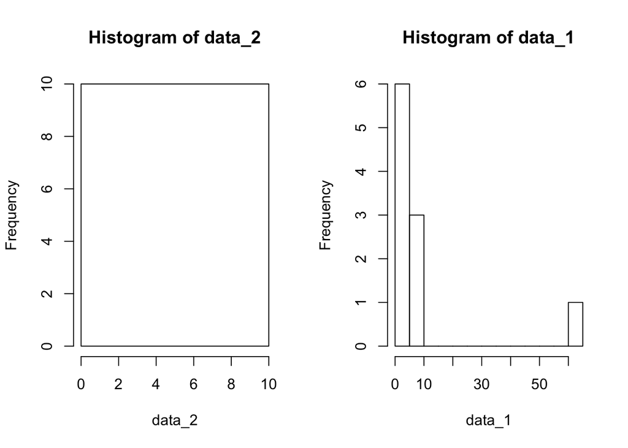

```r
# we want two graphs in one row
par(mfrow=c(1,2))
hist(data_2, breaks = length(data_2))
hist(data_1, breaks = length(data_1))
```

Let’s get back to the $SNR$ formula mentioned earlier. We can see that the higher the $SNR$ the more signal there is available in the data. We can also suspect that in order to retain as much information available in the original data, the transformation vector basis $B'$ which we are searching for, should *follow* the direction of the highest variance in our data set: higher variance = more information.

If we apply this intuition/suspicion to our example of the runner’s data, we should find out that the direction of the highest variance follows the trajectory of the runner’s run. We have already noticed that recording two data points in each data sample is redundant as both data points are **correlated**. Correlation indicates redundancy! We now need to define the data redundancy more formally so that we can transform our two dimensional matrix $X$ into one dimensional vector which points in the direction of the highest possible data variance.

### Variance and Covariance

Let’s talk a little bit more about variance since, clearly, it’s quite important in our quest to find PCA algorithm. Variance is a pretty good measure for single dimenstional data which can be stored in a single vector, but it’s not very helpful when we try to determine if there is any relationship between any types of measurements in our data matrix. We need to find a better measure. Enter Covariance! Covariance is always measured between two arbitrary data sets of the same length defined as followed:

$cov(X,Y) = \frac{\sum_{i=1}^n(X_i - \overline{X})(Y_i - \overline{Y})}{(n-1)}$

In the formula above, $X$ and $Y$ are some arbitrary data vectors holding $n$ number of data samples with their particular mean values $\overline{X}$ and $\overline{Y}$. Interesting property of covariance is that if you calculate covariance with the data set itself, you will get variance as a result:

$cov(X,X) = \frac{\sum_{i=1}^n(X_i - \overline{X})(X_i - \overline{X})}{(n-1)}$

So what does covariance value actually tell us about two data sets? Its exact value is actually not as important as it is its sign: - if the covariance is positive, then both data sets **increase** together - if the covariance is negative, then both data sets **decrease** together - if the covariance is zero, the two data sets are **independent** of each other

This means that two data sets are **not correlated only if their covariance is equal to zero**. Let’s have a look at the covariance in our data set. Luckily R provides a simple function that calculates it for us automatically:

```r
# using covariance function
cov(x, y)
```

```
## [1] 0.8830104
```

```r
# manually crafted based on covariance formula
sum((x-mean(x))*(y-mean(y)))/(length(x)-1)
```

```
## [1] 0.8830104
```

The resulting value is positive which provides a poves our suspicion correct that there is indeed a relationship between the different types of measurements in each data sample (row). Covariance proved to be very helpful when dealing with two dimensional data. But what if we are trying to figure out a possible reltionship in arbitrarily dimensional data?

If we look again at the covariance formula, we should be able to rewrite it into *vectorised* form. We have two data sets $x$ and $y$: the two columns of our measurement data matrix $X$. Let’s substract their mean value from each of their elements and create new vectors $a$ and $b$. These new vectors are also called **zero mean** vectors as once we substract the mean from each of the original values, the newly formed vectors will now have their mean values equal to zero:

$a = x - \frac{\sum_{i=1}^n(x_i)}{n}$ $b = y - \frac{\sum_{i=1}^n(y_i)}{n}$

We can illustrate the zero means by followin R code:

```r
# substract mean from each item in vectors x and y
a <- x - mean(x)
b <- y - mean(y)
mean(a)
```

```
## [1] -1.775923e-16
```

```r
mean(b)
```

```
## [1] 2.486639e-16
```

We can now rewrite the covariance formula in a vectorized form like this:

$cov(a,b) = \frac{1}{n-1}ab^T$

Finally, we can now generalize the covariance formula to an arbitrary number of dimensions. Let’s consider a data matrix $X$ which holds particular measurements $x_1$, $x_2$ $x_n$:

$X = \left[\begin{array} {cc} x_1 \\ x_2 \\ \vdots \end{array}\right]$

We will now define a **covariance matrix** $C_X$ as follows:

$C_X = \frac{1}{n}X^TX$

This matrix turns out to be extremely valuable in our quest to finding the principal components vectors in our vector basis $B'$. Why? Because the covariance matrix carries the information about relationships between all data measurements types stored in particular column vectors of our data matrix $X$.

This might not be obvious from the above equation so let’s have a look at a simple example to understand this better. Let’s have a simple example of three dimesional data matrix i.e. one dimension higher than our original simple example with the runner to illustrate some important properties which the covariance matrix $C_X$ holds. Our new data matrix $X$ will hold three different types of measurements in **column** vectors $x$, $y$ and $z$ each of them adjusted to their zero means value discussed earlier:

$X = \left[\begin{array} {cc} x & y & z \end{array}\right]$

If we now calculate $X$’s covariance matrix $C_X$ we will get the following result:

$C_X = \frac{1}{n}\left(\begin{array} {cc} x & y & z \end{array}\right)^T\left(\begin{array} {cc} x & y & z \end{array}\right) = \frac{1}{n}\left(\begin{array} {cc} x \\ y \\ z \end{array}\right)\left(\begin{array} {cc} x & y & z \end{array}\right) = \left(\begin{array} {cc} cov(x,x) & cov(x,y) & cov(x,z) \\ cov(y,x) & cov(y,y) & cov(y,z) \\ cov(z,x) & cov(z,y) & cov(z,z) \end{array}\right)$

As you might have noticed, the covariance matrix exhibits some very interesting properties: - it is a square symmetric matrix of size $m x m$ where $m$ is a number of data samples in matrix $X$ - diagonal terms are variances of particular measurement type - off-the diagnoal terms are covariances between particular measurement types

Based on our discussion of variance and covariance properties earlier, we know that large values on the diagonals represent interesting structures in the measure data, whilst the values off the diagonals signify the presence of high redundancy - something we are trying to avoid. In light of this knowledge we can now rephrase our original goal to *finding a transformation matrix $B'$ which minimises covariance and maximises variance in the trasnformed data matrix $X'$*. This is the goal of the PCA algorithm.

# Conclusion

In this blog post we have laid down the most important knowledge bricks in our quest of understanding Principal Component Analysis. We should now have a pretty good intuition about the core concepts of PCA. In the next part of the tutorial we will look into implementing PCA and verify how it functions first on our simple two dimensional example and later on more complex multidimensional examples.